# PaRacT Evansetal-18 Data

Manikya Alister

26/08/2022

# Model Comparison

## AIC

```r
load(here("data/evansetal-18/derived/allAIC.Rdata"))
allAIC[,-1]
```

```
##      simple  a-linear    a-power     a-exp a-delayed-power a-delayed-exp
## 1 2738.9385 2315.0689 2145.96200 2073.5348       2129.4667     2056.4918
## 2 2374.5168 2224.5229 2121.72365 2100.9125       2119.2389     2103.1268
## 3  969.4649  878.1462  784.90160  781.6933        785.9589      783.9887
## 4 1856.3506 1805.2265 1804.53823 1797.3516       1802.7338     1799.4731
## 5  965.1508  916.8471  904.95842  912.4617        906.8178      914.9292
## 6 1658.9505 1660.7395 1589.35006 1568.4009       1583.5396     1570.6339
## 7 1607.0729 1538.7464 1438.42493 1429.6818       1433.9272     1431.9064
## 8  230.4516  133.6045  -40.45821 -103.8429        -58.3124     -101.7128
## 9 1186.9112 1173.0373 1176.46037 1190.4872       1178.2014     1188.3486
##    v-linear   v-power     v-exp v-delayed-pow v-delayed-exp   v-a-exp
## 1 2627.4581 2681.6288 2626.4384     2675.2659     2628.7283 2049.6065
## 2 2312.8145 2303.4203 2283.3262     2295.3233     2285.4655 2067.8590
## 3  955.9826  956.3340  956.6996      956.0008      958.8570  782.8647
## 4 1802.5320 1803.6060 1801.2129     1800.6041     1803.9072 1762.4138
## 5  916.9117  920.9086  918.4515      919.8537      920.6572  903.1539
## 6 1643.9093 1632.2402 1631.5513     1633.4908     1632.6884 1556.5637
## 7 1516.4637 1498.1124 1488.1176     1488.7276     1491.0333 1357.7526
## 8  176.5363  135.7760  110.5351      129.6780      107.9434 -115.3947
## 9 1157.7045 1164.2614 1157.3724     1162.5349     1156.7039 1160.9936
```

```r
bestAIC =apply(allAIC[,-1],1,which.min)
bestAIC
```

```
##  1  2  3  4  5  6  7  8  9
## 12 12  4 12 12 12 12 12 11
```

## BIC

```r
load(here("data/evansetal-18/derived/allBIC.Rdata"))
allBIC[,-1]
```

```
##      simple  a-linear    a-power      a-exp a-delayed-power a-delayed-exp
## 1 2753.5048 2334.4905 2170.23905 2097.81183      2158.59919     2085.6243
## 2 2389.1176 2243.9907 2146.05832 2125.24715      2148.44048     2132.3284
## 3  984.0595  897.6056  809.22584  806.01751       815.14797      813.1778
## 4 1868.9521 1822.0285 1825.54078 1818.35410      1827.93690     1824.6762
## 5  979.8860  936.4941  929.51716  937.02047       936.28824      944.3997
## 6 1673.0821 1679.5816 1612.90267 1591.95348      1611.80272     1598.8971
## 7 1621.3332 1557.7602 1462.19212 1453.44898      1462.44782     1460.4270
## 8  246.0033  154.3400  -14.53885  -77.92353       -27.20918      -70.6096
## 9 1201.5952 1192.6160 1200.93372 1214.96050      1207.56942     1217.7167
##    v-linear   v-power     v-exp v-delayed-pow v-delayed-exp    v-a-exp
## 1 2646.8797 2705.9059 2650.7155     2704.3983     2657.8608 2083.59441
## 2 2332.2822 2327.7550 2307.6609     2324.5249     2314.6671 2101.92757
## 3  975.4420  980.6583  981.0238      985.1899      988.0461  816.91867
## 4 1819.3341 1824.6085 1822.2154     1825.8072     1829.1102 1791.81736
## 5  936.5587  945.4674  943.0103      949.3241      950.1277  937.53610
## 6 1662.7514 1655.7928 1655.1039     1661.7540     1660.9515 1589.53735
## 7 1535.4775 1521.8796 1511.8848     1517.2482     1519.5539 1391.02666
## 8  197.2718  161.6954  136.4544      160.7813      139.0466  -79.10759
## 9 1177.2831 1188.7348 1181.8457     1191.9030     1186.0719 1195.25630
```

```r
bestBIC = apply(allBIC[,-1],1,which.min)
bestBIC
```

```
##  1  2  3  4  5  6  7  8  9
## 12 12  4 12  3 12 12 12  7
```

Pretty much agreement between AIC and BIC. Model 12 = Exponential increase in v + exponential decrease in a. Model 4 = exponential decrease in a only.

#### What were the best single models?

What were the best 4 single models? That can inform what 2 parameter models I should run.

```r
# what were the best single models
bestAICsingle = apply(allAIC[,-c(1,12)],1,which.min)
bestAICsingle
```

```
##  1  2  3  4  5  6  7  8  9
## 11 11  4 11 11 11 11 11  9
```

```r
# what were the best single models
bestBICsingle = apply(allBIC[,-c(1,12)],1,which.min)
bestBICsingle
```

```
##  1  2  3  4  5  6  7  8  9
## 11 11  4 11  3 11 11 11  7
```

```r
# what was the second best model?
secBestAICsingle = apply(allAIC[,-c(1,11,12)],1,which.min)
secBestAICsingle
```

```
##  1  2  3  4  5  6  7  8  9
## 10 10  4 10 10 10 10 10  9
```

```r
secBestBICsingle = apply(allBIC[,-c(1,11,12)],1,which.min)
secBestBICsingle
```

```
##  1  2  3  4  5  6  7  8  9
## 10 10  4 10  3 10 10 10  7
```

```r
# what was the best a model?
best_a_AICsingle = apply(allAIC[,2:6],1,which.min)
best_a_AICsingle
```

```
## 1 2 3 4 5 6 7 8 9
## 4 4 4 4 3 4 4 4 2
```

```r
best_a_BICsingle = apply(allBIC[,2:6],1,which.min)
best_a_BICsingle
```

```
## 1 2 3 4 5 6 7 8 9
## 4 4 4 4 3 4 4 4 2
```

best a model is a-exp

```r
# what was the next best a model?
secBest_a_AICsingle = apply(allAIC[,c(2,3,5,6)],1,which.min)
secBest_a_AICsingle
```

```
## 1 2 3 4 5 6 7 8 9
## 3 3 3 3 4 3 3 3 2
```

```r
secBest_a_BICsingle = apply(allBIC[,c(2,3,5,6)],1,which.min)
secBest_a_BICsingle
```

```
## 1 2 3 4 5 6 7 8 9
## 3 3 3 3 4 3 3 3 2
```

#### What 2-parameter change models should I run?

It seems like the delay functions best describe the v- models, but the a- models are better described by the normal power/exponential models. So, I think the best 2 param models to run would be:

```r
bestA = c("a_exp", "a_pow")
bestB = c("v_delayed_exp","v-delayed-pow")
expand.grid(bestA,bestB)
```

```
##    Var1          Var2
## 1 a_exp v_delayed_exp
## 2 a_pow v_delayed_exp
## 3 a_exp v-delayed-pow
## 4 a_pow v-delayed-pow
```

# Visualise Parameters of Best Model (BIC)

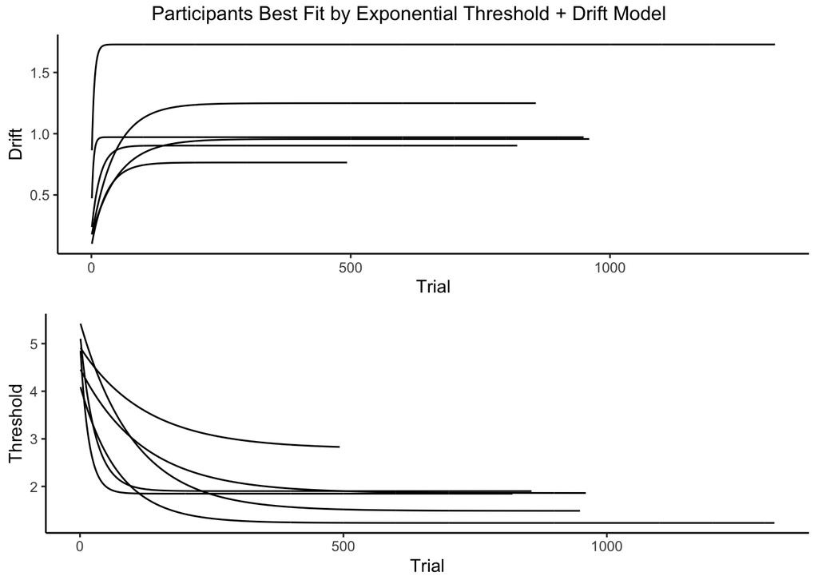

```r
source(here("modelling/evansetal-18/08_param-plot-functions.R"))
v_a_exp_thresh = thresholdPlot("v-a-exp", as.numeric(names(bestBIC[bestBIC == 12])))
v_a_exp_drift = driftPlot("v-a-exp", as.numeric(names(bestBIC[bestBIC == 12])))
gridExtra::grid.arrange(v_a_exp_drift,v_a_exp_thresh, top = "Participants Best Fit by Exponential Threshold + Drift Model")
```

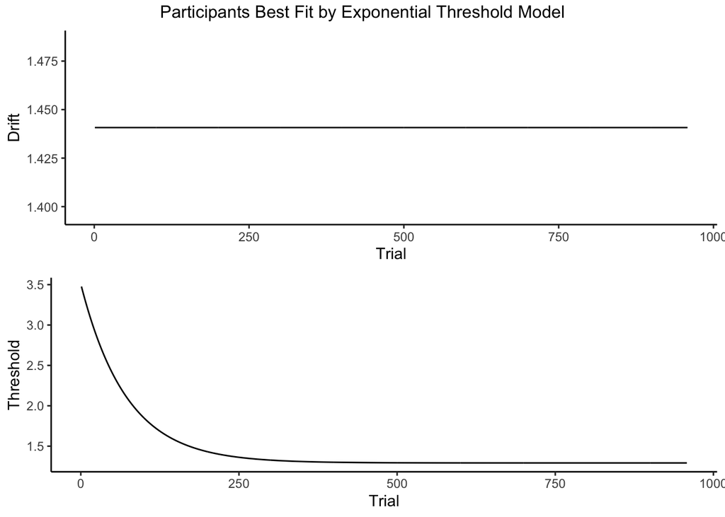

```r
v_simple = driftPlot("simple",as.numeric(names(bestBIC[bestBIC == 4])))
a_exp = thresholdPlot("a-exp",as.numeric(names(bestBIC[bestBIC == 4])))
gridExtra::grid.arrange(v_simple, a_exp, top = "Participants Best Fit by Exponential Threshold Model")
```

[figure not shown]

```r
a_power = thresholdPlot("a-power",as.numeric(names(bestBIC[bestBIC == 3])))
gridExtra::grid.arrange(v_simple, a_power, top = "Participants Best Fit by Power Threshold Model")
```

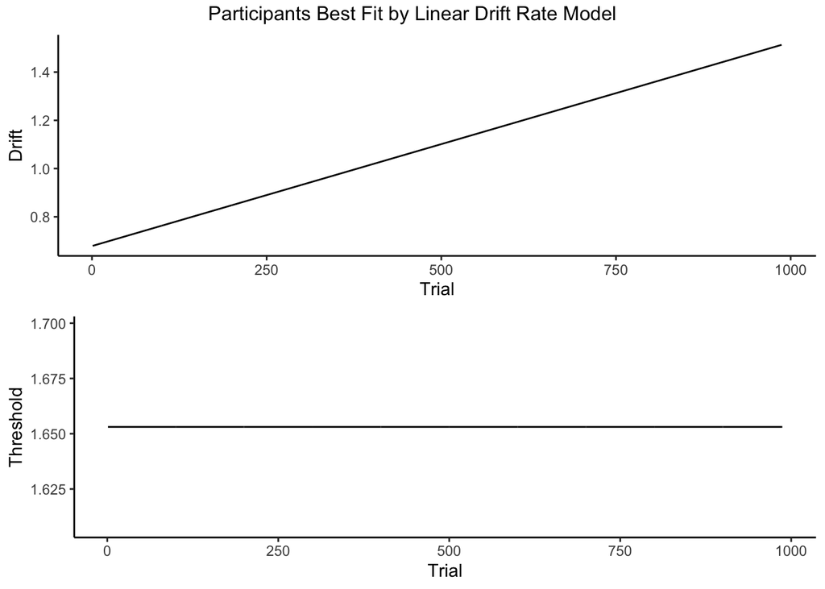

```r
a_simple = thresholdPlot("simple",as.numeric(names(bestBIC[bestBIC == 7])))
v_linear = driftPlot("v-linear",as.numeric(names(bestBIC[bestBIC == 7])))
gridExtra::grid.arrange(v_linear, a_simple, top = "Participants Best Fit by Linear Drift Rate Model")
```

# Visualising parameters of all models for each participant

Bringing up which participants were fit best by which model again for reference

```r
bestAIC
```

```
##  1  2  3  4  5  6  7  8  9
## 12 12  4 12 12 12 12 12 11
```

```r
bestBIC
```

```
##  1  2  3  4  5  6  7  8  9
## 12 12  4 12  3 12 12 12  7
```

### Threshold

I’ve only plotted the simple, linear, power, and exponential models here for clarity. But you can see below that the only participant that doesn’t show an obvious effect of threshold across trials in the plot was participant 9, which makes sense since they were best fit by model 7 (linear drift rate model). So it seems like the model fits are corresponding to the parameter estimates.

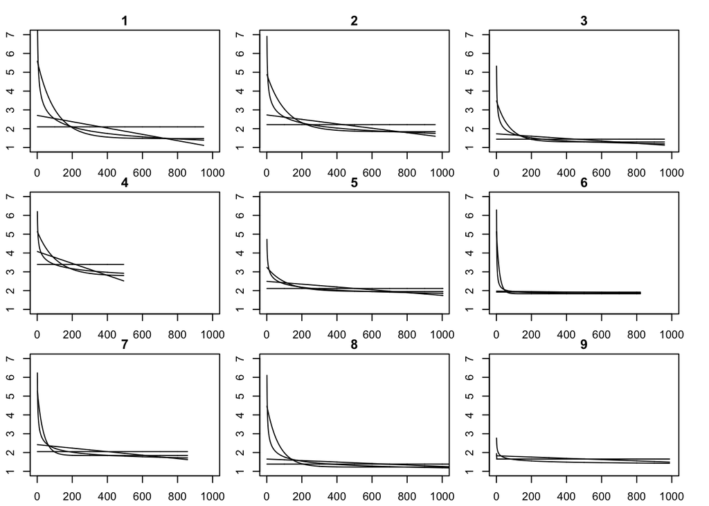

### Drift

Some strange things going on below. For example, most of the change models don’t line up with the estimates of the simple model at all.

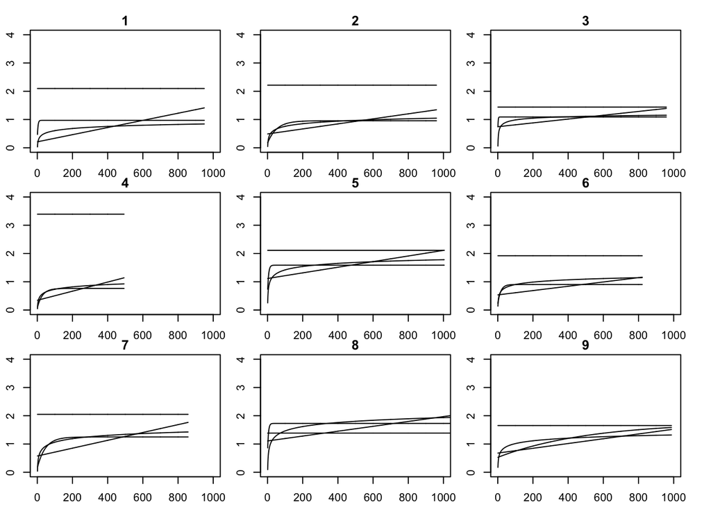

## Same as above for exp/power/exp-delay/power-delay models

### Threshold

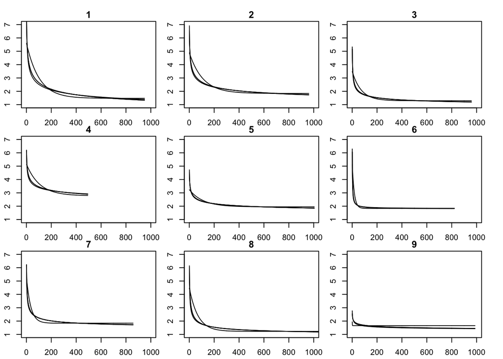

```r
par(omi=rep(0.1, 4), mar=c(1.5,1.5,1.5,1.5), mfrow=c(3,3))
singleParticipant_a(1,models = c("a-power","a-exp","a-delayed-power","a-delayed-exp"))
singleParticipant_a(2,models = c("a-power","a-exp","a-delayed-power","a-delayed-exp"))
singleParticipant_a(3,models = c("a-power","a-exp","a-delayed-power","a-delayed-exp"))
singleParticipant_a(4,models = c("a-power","a-exp","a-delayed-power","a-delayed-exp"))
singleParticipant_a(5,models = c("a-power","a-exp","a-delayed-power","a-delayed-exp"))
singleParticipant_a(6,models = c("a-power","a-exp","a-delayed-power","a-delayed-exp"))
singleParticipant_a(7,models = c("a-power","a-exp","a-delayed-power","a-delayed-exp"))
singleParticipant_a(8,models = c("a-power","a-exp","a-delayed-power","a-delayed-exp"))
singleParticipant_a(9,models = c("a-power","a-exp","a-delayed-power","a-delayed-exp"))
```

### Drift

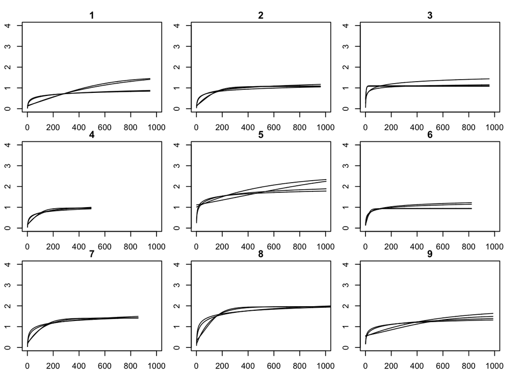

```r
par(omi=rep(0.1, 4), mar=c(1.5,1.5,1.5,1.5), mfrow=c(3,3))
singleParticipant_v(1,models = c("v-power","v-exp","v-delayed-pow","v-delayed-exp"))
singleParticipant_v(2,models = c("v-power","v-exp","v-delayed-pow","v-delayed-exp"))
singleParticipant_v(3,models = c("v-power","v-exp","v-delayed-pow","v-delayed-exp"))
singleParticipant_v(4,models = c("v-power","v-exp","v-delayed-pow","v-delayed-exp"))
singleParticipant_v(5,models = c("v-power","v-exp","v-delayed-pow","v-delayed-exp"))
singleParticipant_v(6,models = c("v-power","v-exp","v-delayed-pow","v-delayed-exp"))
singleParticipant_v(7,models = c("v-power","v-exp","v-delayed-pow","v-delayed-exp"))
singleParticipant_v(8,models = c("v-power","v-exp","v-delayed-pow","v-delayed-exp"))
singleParticipant_v(9,models = c("v-power","v-exp","v-delayed-pow","v-delayed-exp"))
```

# Model Fits (I’m not 100% sure if I’ve done these right)

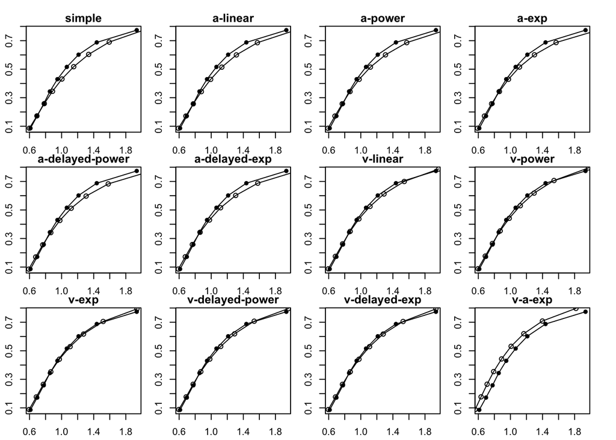

```r
source(here("modelling/evansetal-18/11_model-fits.R"))
par(omi=rep(0.1, 4), mar=c(1.5,1.5,1.5,1.5), mfrow=c(3,4))

plotQuantiles(allSimQuantiles[[models[1]]])

plotQuantiles(allSimQuantiles[[models[2]]])

plotQuantiles(allSimQuantiles[[models[3]]])

plotQuantiles(allSimQuantiles[[models[4]]])

plotQuantiles(allSimQuantiles[[models[5]]])

plotQuantiles(allSimQuantiles[[models[6]]])

plotQuantiles(allSimQuantiles[[models[7]]])

plotQuantiles(allSimQuantiles[[models[8]]])

plotQuantiles(allSimQuantiles[[models[9]]])

plotQuantiles(allSimQuantiles[[models[10]]])

plotQuantiles(allSimQuantiles[[models[11]]])

plotQuantiles(allSimQuantiles[[models[12]]])
```